# Final Project Draft

December 4, 2024

*Authors: Luke Morrison, Camden Cobb, Cameron Marique, Sheryl Wang*

## Introduction

The sinking of the RMS Titanic stands as one of the most profound maritime tragedies in history, its narrative woven into the fabric of our culture’s memory even after more than a century. The harrowing tales of its passengers-marked by courage, sacrifice, and the stark destiny of fate, continue to captivate and mystify. The circumstances surrounding who survived and who did not have sparked countless questions and theories. Were children given priority during the evacuation? Did certain age groups have a better chance of survival?

Through deep analysis, we demonstrate that passengers who survived the Titanic were notably younger than those who did not survive, with an average age difference of about two years. This age difference suggests that younger passengers had better odds of survival during this historic maritime disaster.

## Background

During the maiden voyage of the RMS Titanic in 1912, the ship hit an iceberg and sank, leading to one of the most prolific shipwrecks in history. Because of the Titanic’s historical importance, plenty of data exists about every passenger on this voyage, including data about passengers’ age and their survival status.

In order to investigate whether these two variables are related, we utilized a Titanic dataset on github[^1]. The data in this set was compiled from historical passengers and official records of the RMS Titanic’s maiden voyage in 1912. This was done by using official passenger manifests, Encyclopedia Titanica, survival records from the disaster, ticket purchasing records, and boarding documents to gather historically accurate data.

A single row in the Titanic dataset represents one individual passenger aboard the Titanic’s maiden voyage. We had two variables of interest.

Our first variable of interest was a passenger’s age. This was a numerical variable measured by age in years, and our dataset did contain missing values for this variable. We excluded rows that had missing values. This variable was our independent variable.

Our second variable of interest was whether a passenger survived or not. This was a binary, categorical variable with 0 representing a non-surviving passenger and 1 representing a surviving passenger. There were no missing values for this variable. This was our dependent variable.

To help understand our findings, we created two key visualizations. The first visualization compares the ages between those who survived and those who did not. In this boxplot visualization, each gray dot represents an individual passenger, giving us a complete picture of every age in our dataset. The boxes show where most ages fall for each group - blue for survivors and red for non-survivors. The white diamond in each box marks the average age for that group. Looking at the visualization, we can see that while the difference isn’t dramatic, the survivors’ box and collection of dots sits slightly lower than the non-survivors, showing the tendency for younger passengers to have survived more often.

## Analysis

### Model Statement

Let $X_i$, for $i = 1,...,n_1$ represent the ages of passengers who did not survive the Titanic disaster.

Let $Y_i$ for $i = 1,...,n_2$ represent the ages of passengers who survived the Titanic disaster.

Let $\mu_x$ and $\sigma_x$ be the true mean and standard deviation of the age of the nonsurviving group.

Let $\mu_y$ and $\sigma_y$ be the true mean and standard deviation of the age of the suriving group.

$X_i \sim D_x(\mu_x, \sigma_x)$

$Y_i \sim D_y(\mu_y, \sigma_y)$

### Hypotheses

**Null Hypothesis** ($H_0$): There is no difference in the mean ages of survivors and non-survivors, or:

$H_0: \mu_x - \mu_y = 0$

**Alternative Hypothesis** ($H_A$): There is a difference in the mean ages of survivors and non-survivors, or:

$H_A: \mu_x - \mu_y \neq 0$

### Parameters of Interest

The primary parameter of interest in this analysis is the mean age of two distinct groups: survivors and non-survivors of the Titanic disaster. Specifically, the analysis aims to compare the mean ages between these groups to determine if a statistically significant difference exists.

### Test Statistic and Null Distribution

We employ the two sample Welch’s t-test to evaluate the difference in mean ages between the two groups. Welch’s t-test is chosen because it does not assume equal variances between the groups, making it more robust, especially when sample sizes or variances differ.

The test statistic is calculated as:

$$t = \frac{(\bar{x} - \bar{y}) - (\mu_x
- \mu_y)}{SE(\bar{x}-\bar{y})}$$

Under the null hypothesis $H_0: \mu_x - \mu_y = 0$ the test statistic follows a t-distribution with degree of freedom approximated by Welch’s formula.

### Results

We conducted a two-sample Welch’s t-test to compare the mean ages between survivors and non-survivors

**T-Test Results:**

- **t-statistic:** 2.046
- **Degrees of Freedom:** 598.84
- **p-value:** 0.04119
- **Sample Estimates:**
  - Mean Age (Did Not Survive): 30.626 years
  - Mean Age (Survived): 28.344 years

### P-Value

The p-value obtained from the Welch’s two-sample t-test is $0.04119$. The p-value represents the probability of observing a test statistic as extreme as, or more extreme than, the one calculated ($t = 2.046$) under the assumption that the null hypothesis ($H_0$) is true. In this context, a p-value of $0.04119$ indicates that there is a $4.119\%$ probability of obtaining the observed difference in mean ages, or one more extreme, solely due to random sampling variability if there were actually no difference in the population means.

Given that the p-value of $0.04119$ is less than the significance level of $\alpha = 0.05$, it indicates that there is sufficient evidence to reject the null hypothesis. This suggests that the observed difference in mean ages between survivors and non-survivors is unlikely to have occurred by random chance alone, assuming the null hypothesis is true.

### Graphical Representation

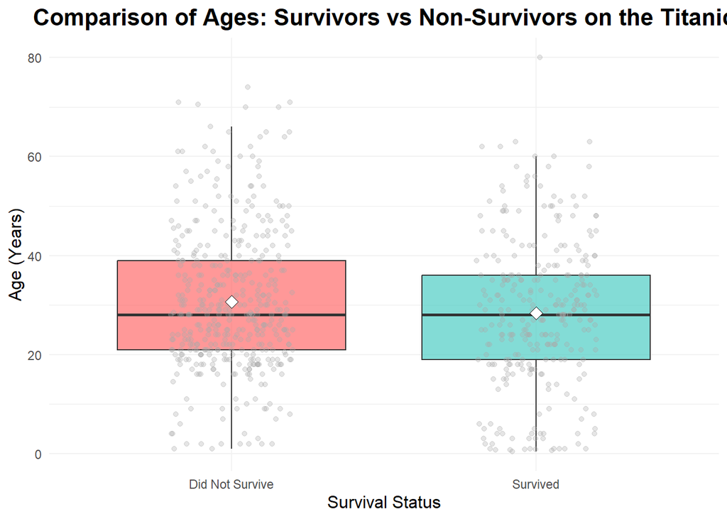

*Figure 1.* Two boxplots representing the distribution of ages of surviving (blue boxplot) and non-surviving (red boxplot) Titanic passengers. Grey dots represent individual passengers, and the white diamond represents the average age of a passenger in each category.

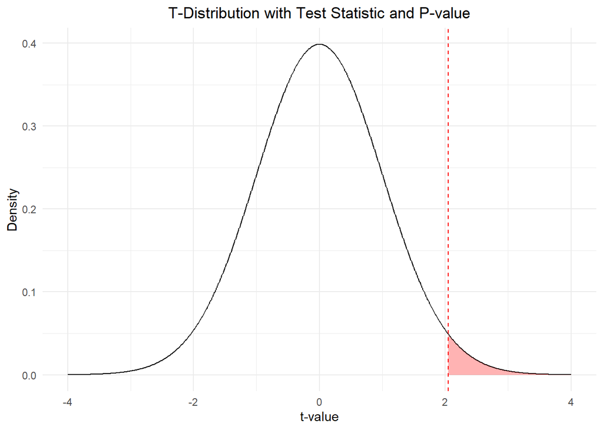

## Discussion

### Further Interpretation

Our analysis reveals that passengers who survived had an average age of about 28 years, compared to about 31 years for those who did not survive.

To put this in practical terms, younger passengers generally had better chances of surviving than older passengers. This finding supports historical accounts suggesting that younger passengers may have had advantages during evacuation, whether due to physical capabilities, prioritization in rescue efforts, or other factors.

### Short-Comings and Future Work

When developing future work using this dataset, a few shortcomings can be discussed. Although it can be refuted at times, many suggest that members of the Titanic allowed on the lifeboats were prioritized based on class and gender, with high-class women being at the top of the list.[^2] Some also suggest that children were prioritized in the lifeboats. Therefore, priority may be another variable that should have been accounted for; however, whether an individual was prioritized can only be determined by anecdotal evidence. Although our analysis could suggest that priority was present, it appears to have been given to younger individuals.

There is a confounding variable in this study: the absence of ages for multiple individuals in the dataset. Although these individuals were excluded from the analysis, there is a possibility that the missing ages of those on the Titanic could skew our data and make our findings less accurate or even incorrect.

Given these limitations, some of our shortcomings can be addressed in future work. Gender is one aspect fully accounted for in our data, so the question of whether it was “women and children first!” can be examined. If more aspects of the survivors could be determined, we could gain a deeper understanding of what made an individual more likely to survive the sinking of the Titanic.

### Conclusion

These findings suggest that younger passengers were slightly more likely to survive the Titanic disaster. However, it is important to recognize the limitations of this study, including the exclusion of other potentially influential factors and the handling of missing data. Future research incorporating additional variables and more sophisticated analytical methods could provide a deeper understanding of the factors that determined survival outcomes during this tragic event.

## Resources

[^1]: https://github.com/awesomedata/awesome-public-datasets/tree/master/Datasets
[^2]: https://www.theguardian.com/science/2010/mar/02/titanic-lusitania-women-children-survival